# NBA Players of the Week

## An analysis by Kevin Chen

## 1. Introduction

The NBA Player of the Week award was created in the 1979-80 season and Julius Erving was its first recipient. The award is reserved to the best performers of the best teams of each regular season week, Monday to Sunday. Initially, only one player in the entire league was awarded each week, but since 2001-02 season, at least two players are selected, one from the Eastern Conference and another from the Western Conference. In rare ocasions, the award has been shared by two players.

Because the Player of the Week award is awarded so frequently, it can be used as a sample of all high performing NBA players.

Here, I will be reading in a dataset of NBA Players of the Week and their attributes such as height, weight, age, and position. I will then perform analysis on the data and extrapolate information accordingly.

## 2. Data Collection and Processing

Here, I'm reading a csv file that I found on Kaggle that lists the NBA Players of the Week from 1985 to the current NBA season. Link to file: https://www.kaggle.com/jacobbaruch/nba-player-of-the-week

```python
import pandas as pd
import numpy as np
import seaborn as sns

nba = pd.read_csv("NBA_player_of_the_week.csv")
nba
```

|  | Active season | Player | Team | Conference | Date | Position | Height | Weight | Age | Draft Year | Seasons in league | Season | Season short | Real_value |
| --- | --- | --- | --- | --- | --- | --- | --- | --- | --- | --- | --- | --- | --- | --- |
| 0 | 0 | Micheal Ray Richardson | New Jersey Nets | NaN | Apr 14, 1985 | PG | 6-5 | 189 | 29 | 1978 | 6 | 1984-1985 | 1985 | 1.0 |
| 1 | 0 | Derek Smith | Los Angeles Clippers | NaN | Apr 7, 1985 | SG | 6-6 | 205 | 23 | 1982 | 2 | 1984-1985 | 1985 | 1.0 |
| 2 | 0 | Calvin Natt | Denver Nuggets | NaN | Apr 1, 1985 | F | 6-6 | 220 | 28 | 1979 | 5 | 1984-1985 | 1985 | 1.0 |
| 3 | 0 | Kareem Abdul-Jabbar | Los Angeles Lakers | NaN | Mar 24, 1985 | C | 7-2 | 225 | 37 | 1969 | 15 | 1984-1985 | 1985 | 1.0 |
| 4 | 0 | Larry Bird | Boston Celtics | NaN | Mar 17, 1985 | SF | 6-9 | 220 | 28 | 1978 | 5 | 1984-1985 | 1985 | 1.0 |
| 5 | 0 | Darrell Griffith | Utah Jazz | NaN | Mar 10, 1985 | SG | 6-4 | 190 | 26 | 1980 | 4 | 1984-1985 | 1985 | 1.0 |
| 6 | 0 | Sleepy Floyd | Golden State Warriors | NaN | Mar 3, 1985 | PG | 6-3 | 170 | 24 | 1982 | 2 | 1984-1985 | 1985 | 1.0 |
| 7 | 0 | Mark Aguirre | Dallas Mavericks | NaN | Feb 24, 1985 | SF | 6-6 | 232 | 25 | 1981 | 3 | 1984-1985 | 1985 | 1.0 |
| 8 | 0 | Magic Johnson | Los Angeles Lakers | NaN | Feb 17, 1985 | PG | 6-9 | 255 | 25 | 1979 | 5 | 1984-1985 | 1985 | 1.0 |
| 9 | 0 | Dominique Wilkins | Atlanta Hawks | NaN | Feb 3, 1985 | SF | 6-7 | 200 | 25 | 1982 | 2 | 1984-1985 | 1985 | 1.0 |
| 10 | 0 | Tom McMillen | Washington Bullets | NaN | Jan 27, 1985 | PF | 6-11 | 215 | 32 | 1974 | 9 | 1984-1985 | 1985 | 1.0 |
| 11 | 0 | Michael Jordan | Chicago Bulls | NaN | Jan 20, 1985 | SG | 6-6 | 215 | 22 | 1984 | 0 | 1984-1985 | 1985 | 1.0 |
| 12 | 0 | World B. Free | Cleveland Cavaliers | NaN | Jan 13, 1985 | G | 6-2 | 185 | 31 | 1975 | 9 | 1984-1985 | 1985 | 1.0 |
| 13 | 0 | Isiah Thomas | Detroit Pistons | NaN | Jan 6, 1985 | PG | 6-1 | 180 | 23 | 1981 | 3 | 1984-1985 | 1985 | 1.0 |
| 14 | 0 | Micheal Ray Richardson | New Jersey Nets | NaN | Dec 30, 1984 | PG | 6-5 | 189 | 29 | 1978 | 6 | 1984-1985 | 1985 | 1.0 |
| 15 | 0 | Terry Cummings | Milwaukee Bucks | NaN | Dec 23, 1984 | PF | 6-9 | 220 | 23 | 1982 | 2 | 1984-1985 | 1985 | 1.0 |
| 16 | 0 | Derek Smith | Los Angeles Clippers | NaN | Dec 16, 1984 | SG | 6-6 | 205 | 23 | 1982 | 2 | 1984-1985 | 1985 | 1.0 |
| 17 | 0 | Orlando Woolridge | Chicago Bulls | NaN | Dec 9, 1984 | PF | 6-9 | 215 | 25 | 1981 | 3 | 1984-1985 | 1985 | 1.0 |
| 18 | 0 | Jack Sikma | Seattle SuperSonics | NaN | Dec 2, 1984 | C | 6-11 | 230 | 29 | 1977 | 7 | 1984-1985 | 1985 | 1.0 |
| 19 | 0 | Bernard King | New York Knicks | NaN | Nov 25, 1984 | SF | 6-7 | 205 | 28 | 1977 | 7 | 1984-1985 | 1985 | 1.0 |
| 20 | 0 | Moses Malone | Philadelphia Sixers | NaN | Nov 18, 1984 | C | 6-10 | 215 | 29 | 1976 | 8 | 1984-1985 | 1985 | 1.0 |
| 21 | 0 | Alex English | Denver Nuggets | NaN | Nov 11, 1984 | SF | 6-7 | 190 | 31 | 1976 | 8 | 1984-1985 | 1985 | 1.0 |
| 22 | 0 | Larry Nance | Phoenix Suns | NaN | Nov 4, 1984 | PF | 6-10 | 205 | 26 | 1981 | 3 | 1984-1985 | 1985 | 1.0 |
| 23 | 0 | Dominique Wilkins | Atlanta Hawks | NaN | Apr 13, 1986 | SF | 6-7 | 200 | 26 | 1982 | 3 | 1985-1986 | 1986 | 1.0 |
| 24 | 0 | Herb Williams | Indiana Pacers | NaN | Apr 6, 1986 | C | 6-10 | 242 | 28 | 1981 | 4 | 1985-1986 | 1986 | 1.0 |
| 25 | 0 | Charles Barkley | Philadelphia Sixers | NaN | Mar 30, 1986 | PF | 6-6 | 252 | 23 | 1984 | 1 | 1985-1986 | 1986 | 1.0 |
| 26 | 0 | Adrian Dantley | Utah Jazz | NaN | Mar 23, 1986 | SF | 6-5 | 208 | 30 | 1976 | 9 | 1985-1986 | 1986 | 1.0 |
| 27 | 0 | Larry Bird | Boston Celtics | NaN | Mar 16, 1986 | SF | 6-9 | 220 | 29 | 1978 | 6 | 1985-1986 | 1986 | 1.0 |
| 28 | 0 | Magic Johnson | Los Angeles Lakers | NaN | Mar 9, 1986 | PG | 6-9 | 255 | 26 | 1979 | 6 | 1985-1986 | 1986 | 1.0 |
| 29 | 0 | Charles Barkley | Philadelphia Sixers | NaN | Mar 2, 1986 | PF | 6-6 | 252 | 23 | 1984 | 1 | 1985-1986 | 1986 | 1.0 |
| ... | ... | ... | ... | ... | ... | ... | ... | ... | ... | ... | ... | ... | ... | ... |
| 1125 | 0 | DeMar DeRozan | Toronto Raptors | East | Dec 26, 2017 | GF | 6-7 | 220 | 28 | 2009 | 8 | 2017-2018 | 2018 | 0.5 |
| 1126 | 0 | Russell Westbrook | Oklahoma City Thunder | West | Dec 26, 2017 | G | 6-3 | 200 | 29 | 2008 | 9 | 2017-2018 | 2018 | 0.5 |
| 1127 | 0 | LeBron James | Cleveland Cavaliers | East | Dec 18, 2017 | F | 6-8 | 250 | 33 | 2003 | 14 | 2017-2018 | 2018 | 0.5 |
| 1128 | 0 | Chris Paul | Houston Rockets | West | Dec 18, 2017 | PG | 6-0 | 175 | 32 | 2005 | 12 | 2017-2018 | 2018 | 0.5 |
| 1129 | 0 | Victor Oladipo | Indiana Pacers | East | Dec 11, 2017 | G | 6-4 | 210 | 25 | 2013 | 4 | 2017-2018 | 2018 | 0.5 |
| 1130 | 0 | Kevin Durant | Golden State Warriors | West | Dec 11, 2017 | SF | 6-9 | 240 | 29 | 2007 | 10 | 2017-2018 | 2018 | 0.5 |
| 1131 | 0 | LeBron James | Cleveland Cavaliers | East | Dec 4, 2017 | F | 6-8 | 250 | 33 | 2003 | 14 | 2017-2018 | 2018 | 0.5 |
| 1132 | 0 | James Harden | Houston Rockets | West | Dec 4, 2017 | SG | 6-5 | 220 | 28 | 2009 | 8 | 2017-2018 | 2018 | 0.5 |
| 1133 | 0 | Goran Dragic | Miami Heat | East | Nov 27, 2017 | G | 6-3 | 190 | 31 | 2008 | 9 | 2017-2018 | 2018 | 0.5 |
| 1134 | 0 | Anthony Davis | New Orleans Pelicans | West | Nov 27, 2017 | PF | 6-10 | 253 | 24 | 2012 | 5 | 2017-2018 | 2018 | 0.5 |
| 1135 | 0 | DeMar DeRozan | Toronto Raptors | East | Nov 20, 2017 | GF | 6-7 | 220 | 28 | 2009 | 8 | 2017-2018 | 2018 | 0.5 |
| 1136 | 0 | Karl-Anthony Towns | Minnesota Timberwolves | West | Nov 20, 2017 | C | 7-0 | 244 | 22 | 2015 | 2 | 2017-2018 | 2018 | 0.5 |
| 1137 | 0 | Tobias Harris | Detroit Pistons | East | Nov 13, 2017 | F | 6-9 | 235 | 25 | 2011 | 6 | 2017-2018 | 2018 | 0.5 |
| 1138 | 0 | Nikola Jokic | Denver Nuggets | West | Nov 13, 2017 | C | 7-0 | 250 | 23 | 2014 | 2 | 2017-2018 | 2018 | 0.5 |
| 1139 | 0 | Kristaps Porzingis | New York Knicks | East | Nov 6, 2017 | FC | 7-3 | 240 | 22 | 2015 | 2 | 2017-2018 | 2018 | 0.5 |
| 1140 | 0 | James Harden | Houston Rockets | West | Nov 6, 2017 | SG | 6-5 | 220 | 28 | 2009 | 8 | 2017-2018 | 2018 | 0.5 |
| 1141 | 0 | Victor Oladipo | Indiana Pacers | East | Oct 30, 2017 | G | 6-4 | 210 | 25 | 2013 | 4 | 2017-2018 | 2018 | 0.5 |
| 1142 | 0 | DeMarcus Cousins | New Orleans Pelicans | West | Oct 30, 2017 | C | 6-11 | 270 | 27 | 2010 | 7 | 2017-2018 | 2018 | 0.5 |
| 1143 | 0 | Giannis Antetokounmpo | Milwaukee Bucks | East | Oct 23, 2017 | F | 6-11 | 242 | 23 | 2013 | 4 | 2017-2018 | 2018 | 0.5 |
| 1144 | 0 | James Harden | Houston Rockets | West | Oct 23, 2017 | SG | 6-5 | 220 | 28 | 2009 | 8 | 2017-2018 | 2018 | 0.5 |
| 1145 | 1 | Nikola Vucevic | Orlando Magic | East | Nov 19, 2018 | PF | 7-0 | 260 | 28 | 2011 | 7 | 2018-2019 | 2019 | 0.5 |
| 1146 | 1 | Anthony Davis | New Orleans Pelicans | West | Nov 19, 2018 | PF | 6-10 | 253 | 25 | 2012 | 6 | 2018-2019 | 2019 | 0.5 |
| 1147 | 1 | Pascal Siakam | Toronto Raptors | East | Nov 12, 2018 | F | 6-9 | 230 | 25 | 2016 | 2 | 2018-2019 | 2019 | 0.5 |
| 1148 | 1 | C.J. McCollum | Portland Trail Blazers | West | Nov 12, 2018 | G | 6-3 | 190 | 27 | 2013 | 5 | 2018-2019 | 2019 | 0.5 |
| 1149 | 1 | Victor Oladipo | Indiana Pacers | East | Nov 5, 2018 | G | 6-4 | 210 | 26 | 2013 | 5 | 2018-2019 | 2019 | 0.5 |
| 1150 | 1 | Russell Westbrook | Oklahoma City Thunder | West | Nov 5, 2018 | G | 6-3 | 200 | 30 | 2008 | 10 | 2018-2019 | 2019 | 0.5 |
| 1151 | 1 | Giannis Antetokounmpo | Milwaukee Bucks | East | Oct 29, 2018 | F | 6-11 | 242 | 24 | 2013 | 5 | 2018-2019 | 2019 | 0.5 |
| 1152 | 1 | Stephen Curry | Golden State Warriors | West | Oct 29, 2018 | G | 6-3 | 190 | 30 | 2009 | 9 | 2018-2019 | 2019 | 0.5 |
| 1153 | 1 | Kemba Walker | Charlotte Hornets | East | Oct 22, 2018 | G | 6-1 | 184 | 28 | 2011 | 7 | 2018-2019 | 2019 | 0.5 |
| 1154 | 1 | Nikola Jokic | Denver Nuggets | West | Oct 22, 2018 | C | 7-0 | 250 | 24 | 2014 | 3 | 2018-2019 | 2019 | 0.5 |

1155 rows × 14 columns

### 2A. Data Tidying

Here, I'm getting rid of irrelevant information such as active season.

There are some inconsistencies regarding position (GF is the same as G-F, etc.) so I'm also normalizing the positions.

There are also inconsistencies regarding teams that have been renamed or relocated (Seattle SuperSonics -> Oklahoma City Thunder, Washington Bullets -> Washington Wizards), so I'm updating those values to reflect the current team. For example, I'm treating the SuperSonics as the Thunder and the Bullets as the Wizards.

However, Charlotte and New Orleans follow special rules.

In 2002, the Charlotte Hornets moved to New Orleans and Charlotte ceased to have an NBA team.

But in 2004, the Charlotte Bobcats were created.

Then, in 2013, the New Orleans Hornets changed their name to the New Orleans Pelicans.

In 2014, the Charlotte Bobcats were renamed back to the Charlotte Hornets.

Kinda confusing, but I'll account for this by standardizing all Charlotte and New Orleans teams to their current names (Charlotte Hornets and New Orleans Pelicans).

I'm also changing the date to the datetime format.

```python
# In terms of position, GF = G-F and FC = F-C, so we merge those values
nba.Position[nba.Position == 'G-F'] = 'GF'
nba.Position[nba.Position == 'F-C'] = 'FC'
# Changing date to datetime
nba.Date = pd.to_datetime(nba.Date)

nba.columns = ['Active season', 'Player', 'Team', 'Conference', 'Date', 'Position', 'Height', 'Weight', 'Age', 'draft_year',
              'seasons_in_league', 'Season', 'season_short', 'Real_value']


# Changing names of teams that don't exist anymore
nba.Team[nba.Team == 'Seattle SuperSonics'] = 'Oklahoma City Thunder'
nba.Team[nba.Team == 'Washington Bullets'] = 'Washington Wizards'

nba.loc[(nba.Team == 'New Orleans Hornets') & (nba.season_short>=2003) & (nba.season_short<=2013), 'Team']='New Orleans Pelicans'
nba.loc[nba.Team =='Charlotte Bobcats', 'Team'] = 'Charlotte Hornets'

# Dropping irrelevant columns
nba.drop('Active season', axis=1, inplace=True)
```

### 2B. More Data Tidying

In the datasset, the height and the weight for each player aren't standardized correctly. Because the height in in Feet-Inches, it's hard to work with, so it makes more sense to convert the height to centimeters.

Since I'm converting the height into cm (metric units), I should convert the weight into metric units as well.

The weight, which is currently in pounds, will be converted to kilograms.

```python
# function for converting height to cm
def cmHeight(x):
    if 'cm' in x:
        return int(x.replace('cm',''))
    else:
        foot = int(x.split('-')[0])
        inches = int(x.split('-')[1])
        return ((foot*12 + inches)*2.54)

# function for converting lbs to kg
def kgWeight(x):
    return (int(x)*0.453592)

# applying to data
nba['Height_cm'] = nba.apply(lambda row : cmHeight(row['Height']),axis = 1)
nba['Weight_kg'] = nba.apply(lambda row : kgWeight(row['Weight']),axis = 1)
nba.drop('Height', axis=1, inplace=True)
nba.drop('Weight', axis=1, inplace=True)
nba
```

|  | Player | Team | Conference | Date | Position | Age | draft_year | seasons_in_league | Season | season_short | Real_value | Height_cm | Weight_kg |
| --- | --- | --- | --- | --- | --- | --- | --- | --- | --- | --- | --- | --- | --- |
| 0 | Micheal Ray Richardson | New Jersey Nets | NaN | 1985-04-14 | PG | 29 | 1978 | 6 | 1984-1985 | 1985 | 1.0 | 195.58 | 85.728888 |
| 1 | Derek Smith | Los Angeles Clippers | NaN | 1985-04-07 | SG | 23 | 1982 | 2 | 1984-1985 | 1985 | 1.0 | 198.12 | 92.986360 |
| 2 | Calvin Natt | Denver Nuggets | NaN | 1985-04-01 | F | 28 | 1979 | 5 | 1984-1985 | 1985 | 1.0 | 198.12 | 99.790240 |
| 3 | Kareem Abdul-Jabbar | Los Angeles Lakers | NaN | 1985-03-24 | C | 37 | 1969 | 15 | 1984-1985 | 1985 | 1.0 | 218.44 | 102.058200 |
| 4 | Larry Bird | Boston Celtics | NaN | 1985-03-17 | SF | 28 | 1978 | 5 | 1984-1985 | 1985 | 1.0 | 205.74 | 99.790240 |
| 5 | Darrell Griffith | Utah Jazz | NaN | 1985-03-10 | SG | 26 | 1980 | 4 | 1984-1985 | 1985 | 1.0 | 193.04 | 86.182480 |
| 6 | Sleepy Floyd | Golden State Warriors | NaN | 1985-03-03 | PG | 24 | 1982 | 2 | 1984-1985 | 1985 | 1.0 | 190.50 | 77.110640 |
| 7 | Mark Aguirre | Dallas Mavericks | NaN | 1985-02-24 | SF | 25 | 1981 | 3 | 1984-1985 | 1985 | 1.0 | 198.12 | 105.233344 |
| 8 | Magic Johnson | Los Angeles Lakers | NaN | 1985-02-17 | PG | 25 | 1979 | 5 | 1984-1985 | 1985 | 1.0 | 205.74 | 115.665960 |
| 9 | Dominique Wilkins | Atlanta Hawks | NaN | 1985-02-03 | SF | 25 | 1982 | 2 | 1984-1985 | 1985 | 1.0 | 200.66 | 90.718400 |
| 10 | Tom McMillen | Washington Wizards | NaN | 1985-01-27 | PF | 32 | 1974 | 9 | 1984-1985 | 1985 | 1.0 | 210.82 | 97.522280 |
| 11 | Michael Jordan | Chicago Bulls | NaN | 1985-01-20 | SG | 22 | 1984 | 0 | 1984-1985 | 1985 | 1.0 | 198.12 | 97.522280 |
| 12 | World B. Free | Cleveland Cavaliers | NaN | 1985-01-13 | G | 31 | 1975 | 9 | 1984-1985 | 1985 | 1.0 | 187.96 | 83.914520 |
| 13 | Isiah Thomas | Detroit Pistons | NaN | 1985-01-06 | PG | 23 | 1981 | 3 | 1984-1985 | 1985 | 1.0 | 185.42 | 81.646560 |
| 14 | Micheal Ray Richardson | New Jersey Nets | NaN | 1984-12-30 | PG | 29 | 1978 | 6 | 1984-1985 | 1985 | 1.0 | 195.58 | 85.728888 |
| 15 | Terry Cummings | Milwaukee Bucks | NaN | 1984-12-23 | PF | 23 | 1982 | 2 | 1984-1985 | 1985 | 1.0 | 205.74 | 99.790240 |
| 16 | Derek Smith | Los Angeles Clippers | NaN | 1984-12-16 | SG | 23 | 1982 | 2 | 1984-1985 | 1985 | 1.0 | 198.12 | 92.986360 |
| 17 | Orlando Woolridge | Chicago Bulls | NaN | 1984-12-09 | PF | 25 | 1981 | 3 | 1984-1985 | 1985 | 1.0 | 205.74 | 97.522280 |
| 18 | Jack Sikma | Oklahoma City Thunder | NaN | 1984-12-02 | C | 29 | 1977 | 7 | 1984-1985 | 1985 | 1.0 | 210.82 | 104.326160 |
| 19 | Bernard King | New York Knicks | NaN | 1984-11-25 | SF | 28 | 1977 | 7 | 1984-1985 | 1985 | 1.0 | 200.66 | 92.986360 |
| 20 | Moses Malone | Philadelphia Sixers | NaN | 1984-11-18 | C | 29 | 1976 | 8 | 1984-1985 | 1985 | 1.0 | 208.28 | 97.522280 |
| 21 | Alex English | Denver Nuggets | NaN | 1984-11-11 | SF | 31 | 1976 | 8 | 1984-1985 | 1985 | 1.0 | 200.66 | 86.182480 |
| 22 | Larry Nance | Phoenix Suns | NaN | 1984-11-04 | PF | 26 | 1981 | 3 | 1984-1985 | 1985 | 1.0 | 208.28 | 92.986360 |
| 23 | Dominique Wilkins | Atlanta Hawks | NaN | 1986-04-13 | SF | 26 | 1982 | 3 | 1985-1986 | 1986 | 1.0 | 200.66 | 90.718400 |
| 24 | Herb Williams | Indiana Pacers | NaN | 1986-04-06 | C | 28 | 1981 | 4 | 1985-1986 | 1986 | 1.0 | 208.28 | 109.769264 |
| 25 | Charles Barkley | Philadelphia Sixers | NaN | 1986-03-30 | PF | 23 | 1984 | 1 | 1985-1986 | 1986 | 1.0 | 198.12 | 114.305184 |
| 26 | Adrian Dantley | Utah Jazz | NaN | 1986-03-23 | SF | 30 | 1976 | 9 | 1985-1986 | 1986 | 1.0 | 195.58 | 94.347136 |
| 27 | Larry Bird | Boston Celtics | NaN | 1986-03-16 | SF | 29 | 1978 | 6 | 1985-1986 | 1986 | 1.0 | 205.74 | 99.790240 |
| 28 | Magic Johnson | Los Angeles Lakers | NaN | 1986-03-09 | PG | 26 | 1979 | 6 | 1985-1986 | 1986 | 1.0 | 205.74 | 115.665960 |
| 29 | Charles Barkley | Philadelphia Sixers | NaN | 1986-03-02 | PF | 23 | 1984 | 1 | 1985-1986 | 1986 | 1.0 | 198.12 | 114.305184 |
| ... | ... | ... | ... | ... | ... | ... | ... | ... | ... | ... | ... | ... | ... |
| 1125 | DeMar DeRozan | Toronto Raptors | East | 2017-12-26 | GF | 28 | 2009 | 8 | 2017-2018 | 2018 | 0.5 | 200.66 | 99.790240 |
| 1126 | Russell Westbrook | Oklahoma City Thunder | West | 2017-12-26 | G | 29 | 2008 | 9 | 2017-2018 | 2018 | 0.5 | 190.50 | 90.718400 |
| 1127 | LeBron James | Cleveland Cavaliers | East | 2017-12-18 | F | 33 | 2003 | 14 | 2017-2018 | 2018 | 0.5 | 203.20 | 113.398000 |
| 1128 | Chris Paul | Houston Rockets | West | 2017-12-18 | PG | 32 | 2005 | 12 | 2017-2018 | 2018 | 0.5 | 182.88 | 79.378600 |
| 1129 | Victor Oladipo | Indiana Pacers | East | 2017-12-11 | G | 25 | 2013 | 4 | 2017-2018 | 2018 | 0.5 | 193.04 | 95.254320 |
| 1130 | Kevin Durant | Golden State Warriors | West | 2017-12-11 | SF | 29 | 2007 | 10 | 2017-2018 | 2018 | 0.5 | 205.74 | 108.862080 |
| 1131 | LeBron James | Cleveland Cavaliers | East | 2017-12-04 | F | 33 | 2003 | 14 | 2017-2018 | 2018 | 0.5 | 203.20 | 113.398000 |
| 1132 | James Harden | Houston Rockets | West | 2017-12-04 | SG | 28 | 2009 | 8 | 2017-2018 | 2018 | 0.5 | 195.58 | 99.790240 |
| 1133 | Goran Dragic | Miami Heat | East | 2017-11-27 | G | 31 | 2008 | 9 | 2017-2018 | 2018 | 0.5 | 190.50 | 86.182480 |
| 1134 | Anthony Davis | New Orleans Pelicans | West | 2017-11-27 | PF | 24 | 2012 | 5 | 2017-2018 | 2018 | 0.5 | 208.28 | 114.758776 |
| 1135 | DeMar DeRozan | Toronto Raptors | East | 2017-11-20 | GF | 28 | 2009 | 8 | 2017-2018 | 2018 | 0.5 | 200.66 | 99.790240 |
| 1136 | Karl-Anthony Towns | Minnesota Timberwolves | West | 2017-11-20 | C | 22 | 2015 | 2 | 2017-2018 | 2018 | 0.5 | 213.36 | 110.676448 |
| 1137 | Tobias Harris | Detroit Pistons | East | 2017-11-13 | F | 25 | 2011 | 6 | 2017-2018 | 2018 | 0.5 | 205.74 | 106.594120 |
| 1138 | Nikola Jokic | Denver Nuggets | West | 2017-11-13 | C | 23 | 2014 | 2 | 2017-2018 | 2018 | 0.5 | 213.36 | 113.398000 |
| 1139 | Kristaps Porzingis | New York Knicks | East | 2017-11-06 | FC | 22 | 2015 | 2 | 2017-2018 | 2018 | 0.5 | 220.98 | 108.862080 |
| 1140 | James Harden | Houston Rockets | West | 2017-11-06 | SG | 28 | 2009 | 8 | 2017-2018 | 2018 | 0.5 | 195.58 | 99.790240 |
| 1141 | Victor Oladipo | Indiana Pacers | East | 2017-10-30 | G | 25 | 2013 | 4 | 2017-2018 | 2018 | 0.5 | 193.04 | 95.254320 |
| 1142 | DeMarcus Cousins | New Orleans Pelicans | West | 2017-10-30 | C | 27 | 2010 | 7 | 2017-2018 | 2018 | 0.5 | 210.82 | 122.469840 |
| 1143 | Giannis Antetokounmpo | Milwaukee Bucks | East | 2017-10-23 | F | 23 | 2013 | 4 | 2017-2018 | 2018 | 0.5 | 210.82 | 109.769264 |
| 1144 | James Harden | Houston Rockets | West | 2017-10-23 | SG | 28 | 2009 | 8 | 2017-2018 | 2018 | 0.5 | 195.58 | 99.790240 |
| 1145 | Nikola Vucevic | Orlando Magic | East | 2018-11-19 | PF | 28 | 2011 | 7 | 2018-2019 | 2019 | 0.5 | 213.36 | 117.933920 |
| 1146 | Anthony Davis | New Orleans Pelicans | West | 2018-11-19 | PF | 25 | 2012 | 6 | 2018-2019 | 2019 | 0.5 | 208.28 | 114.758776 |
| 1147 | Pascal Siakam | Toronto Raptors | East | 2018-11-12 | F | 25 | 2016 | 2 | 2018-2019 | 2019 | 0.5 | 205.74 | 104.326160 |
| 1148 | C.J. McCollum | Portland Trail Blazers | West | 2018-11-12 | G | 27 | 2013 | 5 | 2018-2019 | 2019 | 0.5 | 190.50 | 86.182480 |
| 1149 | Victor Oladipo | Indiana Pacers | East | 2018-11-05 | G | 26 | 2013 | 5 | 2018-2019 | 2019 | 0.5 | 193.04 | 95.254320 |
| 1150 | Russell Westbrook | Oklahoma City Thunder | West | 2018-11-05 | G | 30 | 2008 | 10 | 2018-2019 | 2019 | 0.5 | 190.50 | 90.718400 |
| 1151 | Giannis Antetokounmpo | Milwaukee Bucks | East | 2018-10-29 | F | 24 | 2013 | 5 | 2018-2019 | 2019 | 0.5 | 210.82 | 109.769264 |
| 1152 | Stephen Curry | Golden State Warriors | West | 2018-10-29 | G | 30 | 2009 | 9 | 2018-2019 | 2019 | 0.5 | 190.50 | 86.182480 |
| 1153 | Kemba Walker | Charlotte Hornets | East | 2018-10-22 | G | 28 | 2011 | 7 | 2018-2019 | 2019 | 0.5 | 185.42 | 83.460928 |
| 1154 | Nikola Jokic | Denver Nuggets | West | 2018-10-22 | C | 24 | 2014 | 3 | 2018-2019 | 2019 | 0.5 | 213.36 | 113.398000 |

1155 rows × 13 columns

## 3. Exploratory Analysis & Data Visualization

### 3A. Who are the most and least successful teams (in terms of number of Players of the Week)?

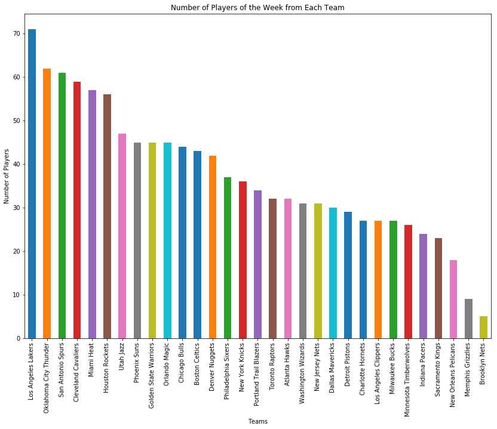

```python
import matplotlib.pyplot as plt

# Plotting teams and their number of players who have recieved the award through a bar graph

ax = nba['Team'].value_counts().plot(kind='bar', figsize=(14,10), title="Number of Players of the Week from Each Team")
ax.set_xlabel("Teams")
ax.set_ylabel("Number of Players")
plt.show()
```

As you can see through the bar graph, the Los Angeles Lakers have the highest number of players of the week (with over 70), while the Brooklyn Nets have the lowest number of players of the week (under 10).

Furthermore, looking at the top five teams on this chart (Los Angeles Lakers, Oklahoma City Thunder, San Antonio Spurs, Cleveland Cavaliers, and Miami Heat), it's easy to see that each of these teams have had generational talent, which is true. More about this later though, when we analyze the top 10 most awarded players.

### 3B. What is the average age of players from each draft year?

[figure not shown]

```python
nba.Age= nba.Age.astype(float)
draft_years= list(nba['draft_year'].unique()) # list of draft years
age_values= [] # list of ages
# for each draft year, get avg age
for i in draft_years:
    x= nba[nba['draft_year'] == i]
    avg = sum(x.Age)/len(x) # taking average
    age_values.append(avg)

data = pd.DataFrame({'draft_years': draft_years, 'age_values':age_values})
new_index = (data['age_values'].sort_values(ascending=False)).index.values
sorted_data = data.reindex(new_index)

# Plotting
plt.figure(figsize=(15,10))
sns.barplot(x=sorted_data['draft_years'], y=sorted_data['age_values'])
plt.xticks(rotation= 90)
plt.xlabel('Age', size=15)
plt.ylabel('Draft Year', size=15)
plt.title('Avg Age of Players in Each Draft', size=15)
plt.show()
```

Also, younger players have more potential and athleticism than older players. It is estimated that the peak for NBA players is usually around the ages of 25-29. While there are special exceptions, generally, NBA players start to decline around the age of 30. Thus, it makes sense to draft younger players so that they can develop and reach their peak.

### 3C. What is the proportion of Players of the Week for each position?

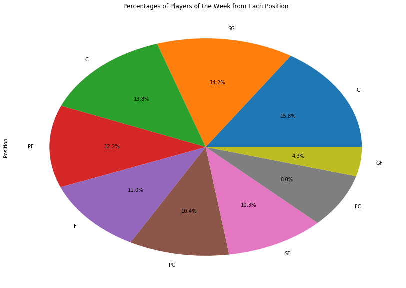

```python
# Plotting position and number of players from that position that have recieved the award through a pie chart
ax2 = nba['Position'].value_counts().plot(kind='pie', figsize=(14,10), autopct='%1.1f%%', title="Percentages of Players of the Week from Each Position")
plt.show()
```

First, I'll explain the basketball positions so that it's easier to understand the chart. In basketball, there are 5 positions: Point Guard, Shooting Guard, Power Forward, Small Forward, and Center.

Traditionally, players who filled these position would solely stick to their role and focus on their task, but basketball has advanced a lot since then and every player these days are required to play two or more positions at one time.

This is due to the nature of the sport where players move around and play flexibly, doing what is required in any given situation.

Here are what the positions are in the context of the dataset:

- PG - Point Guard
- SG - Shooting Guard
- SF - Small Forward
- PF - Power Forward
- C - Center
- G - Guard (Can play Point Guard and Shooting Guard
- F - Forward (Can play either Small Forward and Power Forward)
- GF - Guard-Forward (Can play Shooting Guard and Small Forward)
- FC - Forward-Center (Can play Power Forward and Center)

### 3D. Visualizing BMI vs Position

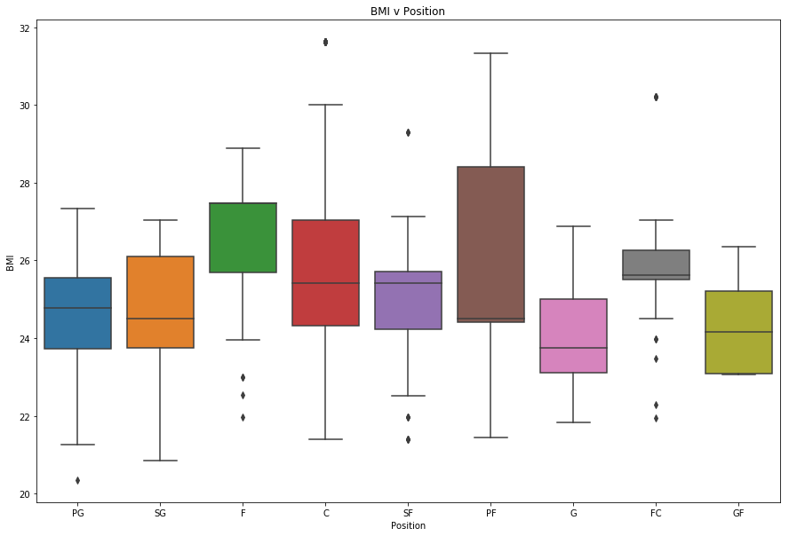

```python
# Calculating BMI and adding it to dataframe
nba['BMI'] = nba['Weight_kg']/((nba['Height_cm']/100)**2)

plt.figure(figsize=(15,10))
plt.title('BMI v Position')
sns.boxplot(x='Position',y='BMI',data=nba)
```

Here, we can see that the upper echelon of BMI belong to Power Forwards and Centers. This makes sense because those positions typically require the largest amount of body mass.

The Center position typically belongs to the biggest men on the court, as they need to play close to the basket to get rebounds and protect the rim. On the offensive play, most centers do not consistently score midrange or beyond the arch. Instead, most of their points should be from offensive rebounds and are also required to block defenders to open other players up for driving to the basket. On the defense, the center is responsible for keeping the opponent from shooting by blocking shots and passes in the vital area. They’re also expected to fight for rebounds as they’re usually taller physically.

Power Forwards are usually the second tallest in the team and are the closest to the centre in terms of physical attributes and playing style but with more speed. Defensively, they are required to have the strength to guard bigger players close to the basket.

In contrast, Guards (PG, SG, G, GF) make up the lower echelon of BMI. This also makes sense because Guards typically need to be agile and fast. This is because they need to be able to drive to the basket quickly, get steals on defense, maneuver around defenders to get open, and dictate the offensive flow for the team.

### 3E. Who are the players who have won the award of Player of the Week the most?

```
Text(0.5,1,'Top 10 Players awarded Player of the Week the most')
```

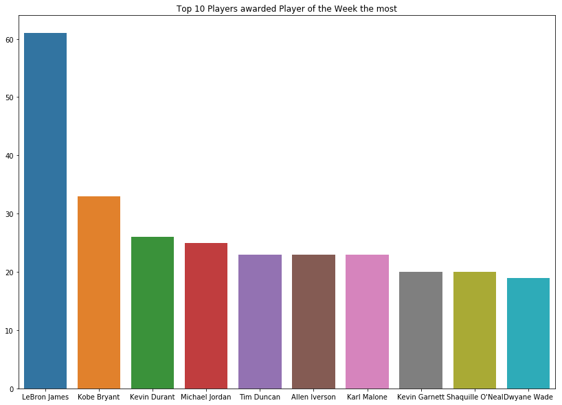

```python
top_players = nba.Player.value_counts()
plt.figure(figsize=(14,10))
sns.barplot(x=top_players[:10].index, y=top_players[:10].values) # showing top 10
plt.title("Top 10 Players awarded Player of the Week the most")
```

Here, we can see that by an extraordinary margin, LeBron James has won Player of the Week more than 60 times. This is almost double that of Kobe Bryant, who is in second place. The next 8 players all, comparatively, have smaller margins between winnings.

Here we can also refer back to the bar chart with the number of players who have won the award by team. Remember that the top five teams were the Los Angeles Lakers, Oklahoma City Thunder, San Antonio Spurs, Cleveland Cavaliers, and Miami Heat.

Each of these top 5 teams have had players in the top 5 of this chart.

- Los Angeles Lakers - Kobe Bryant
- Oklahoma City Thunder - Kevin Durant
- San Antonio Spurs - Tim Duncan
- Cleveland Cavaliers - LeBron James
- Miami Heat - LeBron James

### 3F. Let's visualize the impact of each of the top 5 players awarded Player of the Week

Lets standardize the top 5 players according to their real value. Because the Eastern and Western conferences weren't established until the 2001 NBA season, the Player of the Week for seasons before 2001 only include one player from all NBA teams instead of one player from each conference.

Thus, the real value for those players is 1 and the real value for players after the Eastern and Western conferences were established is .5, since those players had to share the award with another player on the other conference.

For example, LeBron James could've won the Player of the Week award for the Eastern Conference and Kevin Durant could've won the Player of the Week for the Western Conference in the same week.

However, Derek Smith (who played in 1985) would've been the sole recipient of the Player of the Week award because there were no conferences. Thus, LeBron and Durant's real values would be .5 each while Smith's would be 1.

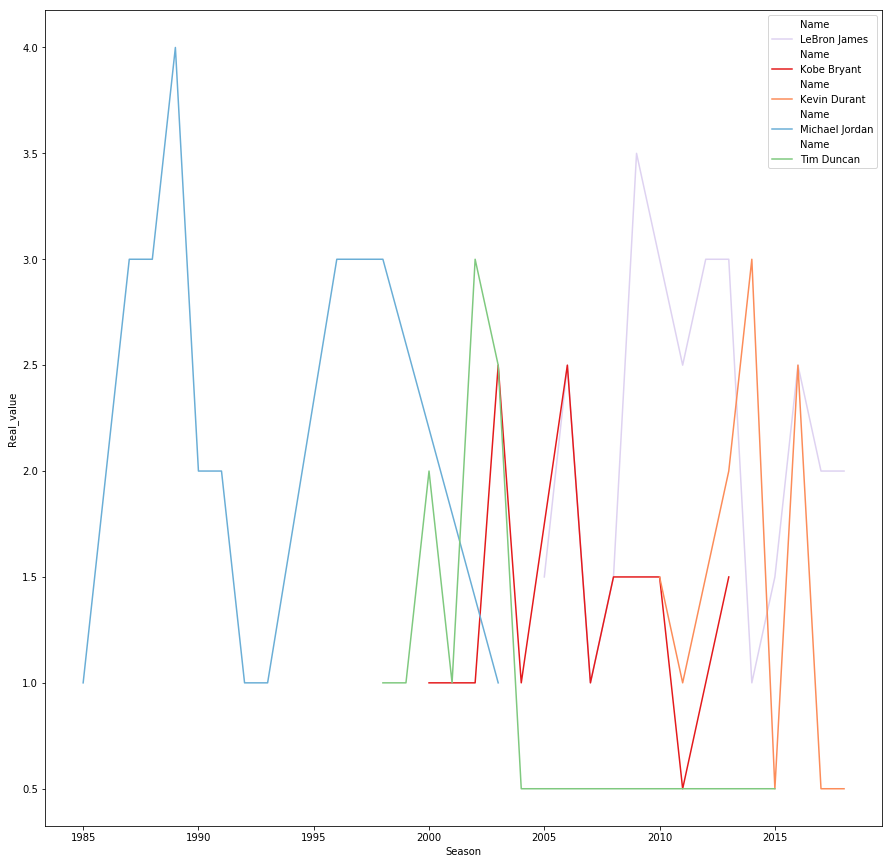

```python
# Creating dataframes for each of the top 5 playesr
df_LBJ=nba[nba.Player=='LeBron James']
df_KB=nba[nba.Player=='Kobe Bryant']
df_KD=nba[nba.Player=='Kevin Durant']
df_MJ=nba[nba.Player=='Michael Jordan']
df_TD=nba[nba.Player=="Tim Duncan"]

# Grouping by season_short (year the season ended)
LBJ=df_LBJ.groupby(['season_short']).sum()
LBJ['Season']=LBJ.index
LBJ['Name']='LeBron James'

KB=df_KB.groupby(['season_short']).sum()
KB['Season']=KB.index
KB['Name']='Kobe Bryant'

KD=df_KD.groupby(['season_short']).sum()
KD['Season']=KD.index
KD['Name']='Kevin Durant'

MJ=df_MJ.groupby(['season_short']).sum()
MJ['Season']=MJ.index
MJ['Name']='Michael Jordan'

TD=df_TD.groupby(['season_short']).sum()
TD['Season']=TD.index
TD['Name']="Tim Duncan"

# Plotting data
plt.figure(figsize=(15,15))
sns.lineplot(x='Season',y='Real_value',data=LBJ,hue='Name', palette='ch:2.5,.25')
sns.lineplot(x='Season',y='Real_value',data=KB,hue='Name', palette='Set1')
sns.lineplot(x='Season',y='Real_value',data=KD,hue='Name', palette='OrRd')
sns.lineplot(x='Season',y='Real_value',data=MJ,hue='Name', palette='Blues')
sns.lineplot(x='Season',y='Real_value',data=TD,hue='Name', palette='Accent')

plt.show()
```

### So which player has had the greatest impact?

In this plot, we can see that Michael Jordan had the greatest impact, reaching a real value of 4.0 around the late 1980s. This makes a lot of sense historically as well.

In the 1987-88 NBA season, Jordan let the league in scoring, averaging 35.0 ppg on 53.3% shooting and won his first Most Valuable Player (MVP) award. In the same year, he was also awarded Defensive Player of the Year, with an average of 1.6 blacks and a league high 3.16 steals per game.

In the 1988-99 NBA season, Jordan again led the league in scoring, averaging 32.5 ppg on 53.8% shooting. During the post-season, Jordan's Bulls reached the Eastern Conference Finals. During the playoffs, Jordan also had a career highlight: "The Shot." This was when he hit a buzzer beater in the final game of the Chicago-Cleveland series and is considered to be one of Jordan's greatest clutch moments. Even in the historical context of the NBA, this shot is considered a classic.

In the 1989-90 season, Jordan, for the third season in a row, led the league in scoring, averaging 33.6 ppg on 52.6% shooting to lead the Chicago Bulls to yet another Eastern Conference Finals.

However, LeBron had outstanding seasons from 2008-2010, rivaling Jordan with a real value of 3.5. Again, this also makes sense in context.

During the 2008-09 NBA season, James finished second in NBA Defensive Player of the Year voting and made his first NBA All-Defensive Team, posting 23 chase-down blocks and a career-high 93 total blocks. He also became only the fourth postmerger player to lead his team in points, rebounds, assists, steals, and blocks in a single season. James also led the Cleveland Cavaliers to a franchise record of 66-16. James also won MVP, becoming the first Cavalier in history to do so.

In the 2009-10 NBA season, James led his team to the best record in the league for the second consecutive season, averaging 29.7 points, 7.3 rebounds, and 8.6 assists on 50% shooting. James also won MVP for the second consecutive season.

It is fitting that both Michael Jordan and LeBron James are so close in this graph, as they are, among basketball fans, in fierce competition over the title of Greatest of All Time. However, at least according to the Player of the Week awards, Jordan seems to have the biggest impact, at least in a single year. Again, this is only according the adjusted real values of the number of Player of the Week awards.

## Additional Resources

Hoped you enjoyed the analysis and learned more about basketball! Here are the links to some of the resources that I used and other links that may be beneficial for you to gain more information about the topic and basketball as a whole:

- Study of NBA players and when they decline: http://harvardsportsanalysis.org/2017/11/what-happens-to-nba-players-when-they-age/
- Overview of basketball positions and roles: https://www.myactivesg.com/sports/basketball/how-to-play/basketball-rules/basketball-positions-and-roles
- Extremely useful website for statistics of NBA players: https://www.basketball-reference.com/
- List of NBA awards: https://en.wikipedia.org/wiki/List_of_National_Basketball_Association_awards
- Really cool and useful guide to the current (2018-19) NBA season for new fans: https://www.reddit.com/r/nba/comments/9jzdij/a_new_fans_guide_to_the_nba_20182019_season/